**Багров Матвей, 3530901/00201**

# Лабораторная работа №3

## Упражнение 1

Импортируем нужные библиотеки и файлы, импортируем файл thinkdsp.py необходимый для работы

```python
import os
if not os.path.exists('thinkdsp.py'):
    !wget https://github.com/AllenDowney/ThinkDSP/raw/master/code/thinkdsp.py
from thinkdsp import *
```

[output not shown]

В примере с утечкой заменим окно Хэмминга одним из окон, предоставляемых NumPy, и посмотрим, как они влияют на утечку. Рассмотреим спектр непериодической волны:

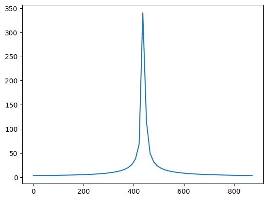

```python
signal = SinSignal(freq=440)
duration = signal.period * 30.25
wave = signal.make_wave(duration)
spectrum = wave.make_spectrum()
spectrum.plot(high=880)
```

Спектр этой волны с применением окна Хэмминга:

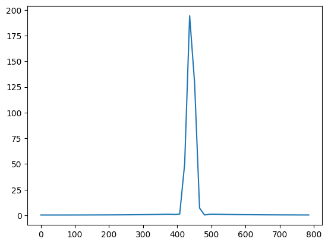

```python
wave.hamming()
wave.make_spectrum().plot(high=800)
```

Окно Бартлетта:

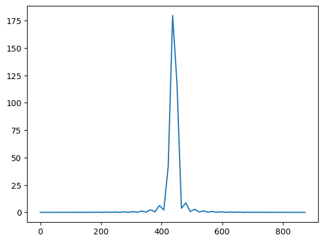

```python
wave = signal.make_wave(duration)
wave.ys *= np.bartlett(len(wave.ys))
spectrum = wave.make_spectrum()
spectrum.plot(high=880)
```

Теперь на частотах, близких к пику, график выглядит как ломанная Окно Блэкмана:

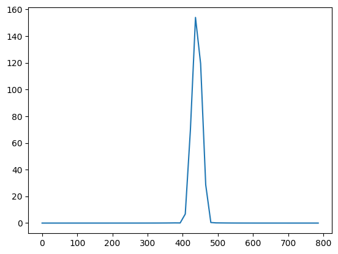

```python
wave = signal.make_wave(duration)
wave.ys *= np.blackman(len(wave))
wave.make_spectrum().plot(high=800)
```

Этот график очень похож на полученный с помощью окна Хэмминга

Окно Ханна:

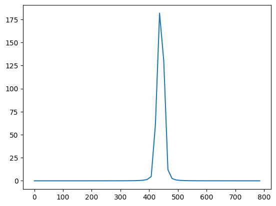

```python
wave = signal.make_wave(duration)
wave.ys *= np.hanning(len(wave))
wave.make_spectrum().plot(high=800)
```

Все оконные функции хорошо справились с функцией борьбы с растеканием спектра.

## Упражнение 2

Напишем класс SawtoothChirp, расширающий Chirp и переопределяющий evalute для генерации пилообразного сигнала с линейно увеличивающейся (или уменьшающейся) частотой. Изобразим эскиз спектрограммы этого сигнала, распечатаем ее.

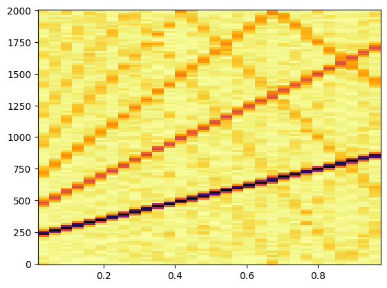

```python
class SawtoothChirp(Chirp):
  def evaluate(self, ts):
    freqs = np.linspace(self.start, self.end, len(ts))
    dts = np.diff(ts, prepend=0)
    dphis = PI2 * freqs * dts
    phases = np.cumsum(dphis)
    cycles = phases / PI2
    frac, _ = np.modf(cycles)
    ys =  normalize(unbias(frac), self.amp)
    return ys

signal = SawtoothChirp(start=220, end=880)
wave = signal.make_wave(duration=1, framerate=4000)
sp = wave.make_spectrogram(256)
sp.plot()
```

Жирная черная линия - это наша основная частота, красные линии - это частоты с биением, которые "отскакивают" от завертки

Эффект биений очевиден, попробуем их услышать.

```python
wave.make_audio()
```

[interactive chart not shown]

Слышно, как частота постепенно увеливается.

## Упражнение 3

Создадим пилообразный чирп, меняющийся от 2500 до 3000 Гц, и на его основе сгенерируем сигнал длительностью 1 сек. и с частотой 20 кГц.

[interactive chart not shown]

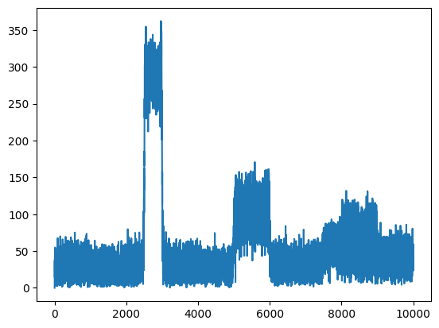

```python
signal = SawtoothChirp(start=2500, end=3000)
wave = signal.make_wave(duration=1, framerate=20000)
wave.make_spectrum().plot()
wave.make_audio()
```

Между частотами 2500 и 3000 можно увидеть возвышенность. Последующие гормоники (от 5000 до 6000 и от 7500 до 9000) имеют меньший дипазон амплитуды

## Упражнение 4

Возьмем пример глиссандо из учебного репозитория:

```python
if not os.path.exists('72475__rockwehrmann__glissup02.wav'):
    !wget https://github.com/AllenDowney/ThinkDSP/raw/master/code/72475__rockwehrmann__glissup02.wav
```

[output not shown]

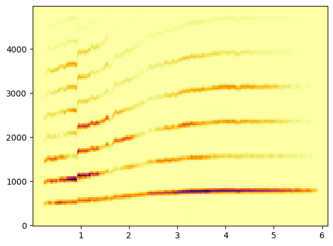

```python
wave = read_wave('72475__rockwehrmann__glissup02.wav')
wave.make_spectrogram(1024).plot(high=5000)
```

```python
wave.make_audio()
```

[interactive chart not shown]

Спектограмма похожа на пилообразный чирп.

## Упражнение 5

Напишем класс TromboneGliss, расширяющий Chirp и предоставляющий evaluate. Создадим сигнал, имитирующий глиссандо на тромбоне от C3 до F3, и обратно до C3. C3 - 262 Гц; F3 - 349 Гц.

```python
class TromboneGliss(Chirp):
    def evaluate(self, ts):
      l1, l2 = 1.0 / self.start, 1.0 / self.end
      lengths = np.linspace(l1, l2, len(ts))
      freqs = 1 / lengths
      dts = np.diff(ts, prepend=0)
      dphis = PI2 * freqs * dts
      phases = np.cumsum(dphis)
      ys = self.amp * np.cos(phases)
      return ys
```

```python
signal1 = TromboneGliss(262, 349)
wave1 = signal1.make_wave(duration=1)
wave1.make_audio()
```

[interactive chart not shown]

```python
signal2 = TromboneGliss(349, 262)
wave2 = signal2.make_wave(duration=1)
wave2.make_audio()
```

[interactive chart not shown]

```python
wave = wave1 | wave2
wave.make_audio()
```

[interactive chart not shown]

Отчетливо слышен переход между частями

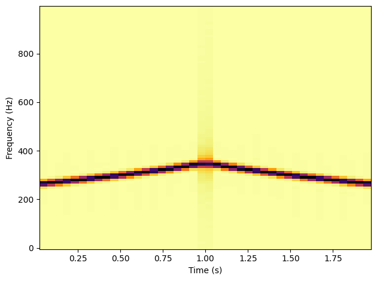

```python
spectrogram = wave.make_spectrogram(1024)
spectrogram.plot(high=1000)
decorate(xlabel='Time (s)', ylabel='Frequency (Hz)')
```

## Упражнение 6

Возьмем пример звуков гласных из учебного репозитория:

```python
if not os.path.exists('87778__marcgascon7__vocals.wav'):
    !wget https://github.com/AllenDowney/ThinkDSP/raw/master/code/87778__marcgascon7__vocals.wav
```

[output not shown]

```python
wave = read_wave('87778__marcgascon7__vocals.wav')
wave.make_audio()
```

[interactive chart not shown]

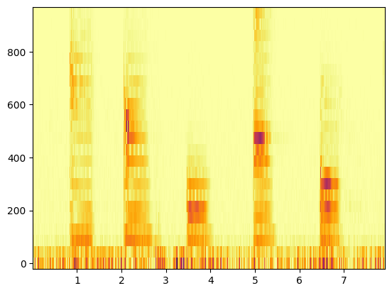

```python
wave.make_spectrogram(1024).plot(high=1000)
```

Пики на спектограмме являются нашими гласными, полосы снизу - это фоновый шум